# Project: Investigate a Dataset (Gapminder World!)

- Introduction
- Data Wrangling
- Exploratory Data Analysis
- Conclusions

## Introduction

#### This dataset is about how people live thier lives in different countries, tracked across the years on a number of different indecators.

#### By using this dataset,I aim to get an answer for each of the following questions:

1-The impact of the aid received on the growth rate in Egypt during the period from 2000 to 2010.

2- The highest growth contries in 2010

3-Copmaring number of malaria death and murder death in Nigeria in 2005

```python
import pandas as pd
import numpy as np
import matplotlib.pyplot as plt
import seaborn as sns
% matplotlib inline
```

## Data Wrangling

### Gather

```python
aid_recieved = pd.read_csv('aid_received_total_us_inflation_adjusted.csv')
```

```python
GDP = pd.read_csv('gdp_total_yearly_growth.csv')
```

```python
malaria_death = pd.read_csv('malaria_number_of_deaths_reported.csv')
```

```python
Murder_deaths = pd.read_csv('murder_total_deaths.csv')
```

### Assess

```python
aid_recieved.head()
```

|  | country | 1960 | 1961 | 1962 | 1963 | 1964 | 1965 | 1966 | 1967 | 1968 | ... | 2009 | 2010 | 2011 | 2012 | 2013 | 2014 | 2015 | 2016 | 2017 | 2018 |
| --- | --- | --- | --- | --- | --- | --- | --- | --- | --- | --- | --- | --- | --- | --- | --- | --- | --- | --- | --- | --- | --- |
| 0 | Afghanistan | 1.170000e+08 | 2.380000e+08 | 1.170000e+08 | 2.410000e+08 | 3.090000e+08 | 3.790000e+08 | 350000000.0 | 268000000.0 | 186000000.0 | ... | 6.260000e+09 | 6.240000e+09 | 6.430000e+09 | 6.320000e+09 | 4.860000e+09 | 4.680000e+09 | 4.340000e+09 | 4.140000e+09 | 3.810000e+09 | 3.650000e+09 |
| 1 | Albania | NaN | NaN | NaN | NaN | NaN | NaN | NaN | NaN | NaN | ... | 3.250000e+08 | 3.390000e+08 | 3.300000e+08 | 3.210000e+08 | 2.430000e+08 | 2.510000e+08 | 3.350000e+08 | 1.740000e+08 | 1.680000e+08 | 3.250000e+08 |
| 2 | Algeria | 3.030000e+09 | 3.620000e+09 | 3.070000e+09 | 2.070000e+09 | 1.600000e+09 | 1.020000e+09 | 842000000.0 | 711000000.0 | 764000000.0 | ... | 2.680000e+08 | 1.840000e+08 | 1.690000e+08 | 1.370000e+08 | 1.840000e+08 | 1.400000e+08 | 7.240000e+07 | 1.480000e+08 | 1.750000e+08 | 1.360000e+08 |
| 3 | Angola | -3.900000e+05 | 2.660000e+08 | NaN | 2.400000e+05 | NaN | 1.210000e+07 | 28500000.0 | 174000000.0 | 80000.0 | ... | 2.380000e+08 | 2.280000e+08 | 1.840000e+08 | 2.330000e+08 | 2.660000e+08 | 2.180000e+08 | 3.990000e+08 | 2.120000e+08 | 2.230000e+08 | 1.540000e+08 |
| 4 | Antigua and Barbuda | NaN | NaN | NaN | NaN | NaN | NaN | NaN | NaN | NaN | ... | 3.950000e+06 | 1.720000e+07 | 1.200000e+07 | 1.810000e+06 | 1.460000e+06 | 2.330000e+06 | 1.620000e+06 | -1.900000e+05 | 9.920000e+06 | 1.610000e+07 |

5 rows × 60 columns

```python
aid_recieved.info()
```

```
<class 'pandas.core.frame.DataFrame'>
RangeIndex: 157 entries, 0 to 156
Data columns (total 60 columns):
country    157 non-null object
1960       105 non-null float64
1961       112 non-null float64
1962       105 non-null float64
1963       111 non-null float64
1964       108 non-null float64
1965       109 non-null float64
1966       117 non-null float64
1967       118 non-null float64
1968       114 non-null float64
1969       116 non-null float64
1970       114 non-null float64
```

[output cut: 50 more lines]

```python
aid_recieved.shape
```

```
(157, 60)
```

```python
aid_recieved.describe()
```

|  | 1960 | 1961 | 1962 | 1963 | 1964 | 1965 | 1966 | 1967 | 1968 | 1969 | ... | 2009 | 2010 | 2011 | 2012 | 2013 | 2014 | 2015 | 2016 | 2017 | 2018 |
| --- | --- | --- | --- | --- | --- | --- | --- | --- | --- | --- | --- | --- | --- | --- | --- | --- | --- | --- | --- | --- | --- |
| count | 1.050000e+02 | 1.120000e+02 | 1.050000e+02 | 1.110000e+02 | 1.080000e+02 | 1.090000e+02 | 1.170000e+02 | 1.180000e+02 | 1.140000e+02 | 1.160000e+02 | ... | 1.430000e+02 | 1.430000e+02 | 1.400000e+02 | 1.400000e+02 | 1.400000e+02 | 1.390000e+02 | 1.390000e+02 | 1.390000e+02 | 1.390000e+02 | 1.360000e+02 |
| mean | 2.478081e+08 | 2.792121e+08 | 3.052235e+08 | 3.040824e+08 | 3.178350e+08 | 3.472581e+08 | 3.239287e+08 | 3.214369e+08 | 3.000388e+08 | 2.821966e+08 | ... | 5.884384e+08 | 5.926591e+08 | 6.158278e+08 | 6.178118e+08 | 6.801655e+08 | 6.710993e+08 | 7.129022e+08 | 7.610547e+08 | 7.893906e+08 | 7.861818e+08 |
| std | 6.730003e+08 | 6.515594e+08 | 6.547924e+08 | 7.769232e+08 | 8.998356e+08 | 9.180873e+08 | 8.566124e+08 | 9.059795e+08 | 6.795026e+08 | 6.382387e+08 | ... | 8.708707e+08 | 8.682855e+08 | 9.429071e+08 | 8.658149e+08 | 9.855911e+08 | 9.340461e+08 | 9.446756e+08 | 1.139728e+09 | 1.265363e+09 | 1.342861e+09 |
| min | -6.490000e+07 | -1.070000e+08 | -6.520000e+07 | -1.630000e+07 | -3.630000e+08 | -4.830000e+08 | -1.030000e+08 | -9.550000e+06 | -2.760000e+07 | -1.000000e+06 | ... | -5.110000e+06 | -1.650000e+08 | -5.030000e+08 | -6.940000e+07 | -6.080000e+08 | -9.190000e+08 | -3.480000e+08 | -7.500000e+08 | -9.900000e+08 | -7.450000e+08 |
| 25% | 1.390000e+06 | 9.692500e+06 | 3.540000e+07 | 3.390000e+07 | 2.777500e+07 | 3.940000e+07 | 2.870000e+07 | 3.422500e+07 | 4.202500e+07 | 4.477500e+07 | ... | 9.570000e+07 | 9.265000e+07 | 8.987500e+07 | 8.607500e+07 | 7.930000e+07 | 8.505000e+07 | 7.905000e+07 | 8.175000e+07 | 9.865000e+07 | 9.755000e+07 |
| 50% | 5.700000e+07 | 6.650000e+07 | 7.750000e+07 | 7.040000e+07 | 1.085000e+08 | 1.150000e+08 | 1.100000e+08 | 1.030000e+08 | 1.130000e+08 | 9.660000e+07 | ... | 2.780000e+08 | 3.060000e+08 | 2.995000e+08 | 2.655000e+08 | 2.665000e+08 | 2.950000e+08 | 3.360000e+08 | 3.130000e+08 | 2.800000e+08 | 3.780000e+08 |
| 75% | 1.830000e+08 | 2.067500e+08 | 2.380000e+08 | 1.985000e+08 | 2.382500e+08 | 3.110000e+08 | 2.830000e+08 | 2.695000e+08 | 2.795000e+08 | 2.302500e+08 | ... | 6.390000e+08 | 6.595000e+08 | 6.867500e+08 | 8.457500e+08 | 8.332500e+08 | 8.410000e+08 | 9.990000e+08 | 1.016000e+09 | 9.650000e+08 | 9.757500e+08 |
| max | 5.470000e+09 | 4.790000e+09 | 4.680000e+09 | 6.650000e+09 | 8.230000e+09 | 8.510000e+09 | 8.110000e+09 | 8.740000e+09 | 5.810000e+09 | 5.410000e+09 | ... | 6.260000e+09 | 6.240000e+09 | 6.430000e+09 | 6.320000e+09 | 4.950000e+09 | 4.680000e+09 | 4.650000e+09 | 8.490000e+09 | 1.040000e+10 | 1.080000e+10 |

8 rows × 59 columns

```python
GDP.head()
```

|  | country | 1801 | 1802 | 1803 | 1804 | 1805 | 1806 | 1807 | 1808 | 1809 | ... | 2004 | 2005 | 2006 | 2007 | 2008 | 2009 | 2010 | 2011 | 2012 | 2013 |
| --- | --- | --- | --- | --- | --- | --- | --- | --- | --- | --- | --- | --- | --- | --- | --- | --- | --- | --- | --- | --- | --- |
| 0 | Afghanistan | 0.000 | 0.000 | 0.000 | 0.000 | 0.000 | 0.000 | 0.000 | 0.000 | 0.000 | ... | 6.55 | 12.40 | 4.56 | 13.600 | 2.50 | 20.20 | 8.04 | 6.98 | 14.80 | 4.47 |
| 1 | Albania | 0.418 | 0.418 | 0.418 | 0.418 | 0.418 | 0.418 | 0.418 | 0.418 | 0.418 | ... | 5.97 | 5.53 | 5.77 | 5.850 | 7.24 | 3.28 | 3.36 | 2.86 | 2.64 | 2.06 |
| 2 | Algeria | 0.356 | 0.356 | 0.356 | 0.356 | 0.356 | 0.356 | 0.356 | 0.356 | 0.356 | ... | 5.41 | 5.38 | 1.72 | 3.420 | 2.02 | 1.70 | 3.57 | 2.31 | 2.58 | 2.99 |
| 3 | Andorra | 0.166 | 0.166 | 0.166 | 0.166 | 0.166 | 0.166 | 0.166 | 0.166 | 0.166 | ... | 8.64 | 7.80 | 4.97 | 0.161 | -4.22 | -5.06 | -3.43 | -2.83 | NaN | NaN |
| 4 | Angola | 0.425 | 0.425 | 0.425 | 0.425 | 0.425 | 0.425 | 0.425 | 0.425 | 0.425 | ... | 11.20 | 20.50 | 18.60 | 23.200 | 13.80 | 2.39 | 3.45 | 3.87 | 4.96 | 3.79 |

5 rows × 214 columns

```python
GDP.info()
```

```
<class 'pandas.core.frame.DataFrame'>
RangeIndex: 194 entries, 0 to 193
Columns: 214 entries, country to 2013
dtypes: float64(213), object(1)
memory usage: 324.4+ KB
```

```python
GDP.shape
```

```
(194, 214)
```

```python
GDP.describe()
```

|  | 1801 | 1802 | 1803 | 1804 | 1805 | 1806 | 1807 | 1808 | 1809 | 1810 | ... | 2004 | 2005 | 2006 | 2007 | 2008 | 2009 | 2010 | 2011 | 2012 | 2013 |
| --- | --- | --- | --- | --- | --- | --- | --- | --- | --- | --- | --- | --- | --- | --- | --- | --- | --- | --- | --- | --- | --- |
| count | 193.000000 | 193.000000 | 193.000000 | 193.000000 | 193.000000 | 193.000000 | 193.000000 | 193.000000 | 193.000000 | 193.000000 | ... | 194.000000 | 194.000000 | 193.000000 | 193.000000 | 193.000000 | 193.000000 | 193.000000 | 193.000000 | 188.000000 | 184.000000 |
| mean | 0.218373 | 0.250831 | 0.185797 | 0.182472 | 0.227666 | 0.222255 | 0.246230 | 0.014775 | 0.192783 | 0.370757 | ... | 5.942258 | 5.397034 | 5.760171 | 5.866194 | 4.593883 | -0.239553 | 4.361879 | 3.710679 | 3.603428 | 3.076822 |
| std | 0.542447 | 0.626350 | 0.471874 | 0.677106 | 0.909371 | 0.516644 | 0.933217 | 1.460582 | 0.781679 | 1.653471 | ... | 6.292875 | 4.439756 | 5.054190 | 4.454218 | 8.006089 | 5.703545 | 4.364341 | 6.442710 | 8.944598 | 4.608508 |
| min | -0.955000 | -0.116000 | -2.000000 | -5.830000 | -4.890000 | -0.579000 | -3.870000 | -12.100000 | -5.190000 | -7.440000 | ... | -6.370000 | -6.040000 | -20.300000 | -10.800000 | -18.100000 | -18.200000 | -7.580000 | -61.200000 | -47.500000 | -36.000000 |
| 25% | 0.000000 | 0.000000 | 0.000000 | 0.000000 | 0.000000 | 0.000000 | 0.000000 | 0.000000 | 0.000000 | 0.000000 | ... | 3.202500 | 3.005000 | 3.530000 | 3.350000 | 1.530000 | -3.830000 | 1.850000 | 1.760000 | 0.778750 | 1.205000 |
| 50% | 0.023600 | 0.023600 | 0.023600 | 0.023600 | 0.023600 | 0.023600 | 0.023600 | 0.023600 | 0.023600 | 0.023600 | ... | 4.865000 | 5.080000 | 5.280000 | 5.680000 | 3.830000 | 0.107000 | 3.860000 | 3.810000 | 3.170000 | 3.135000 |
| 75% | 0.166000 | 0.171000 | 0.166000 | 0.166000 | 0.171000 | 0.171000 | 0.171000 | 0.166000 | 0.171000 | 0.171000 | ... | 7.340000 | 6.960000 | 7.710000 | 7.750000 | 6.500000 | 3.540000 | 6.690000 | 6.070000 | 5.832500 | 5.032500 |
| max | 3.820000 | 4.910000 | 3.220000 | 4.700000 | 7.160000 | 3.830000 | 8.800000 | 6.160000 | 6.930000 | 15.100000 | ... | 58.500000 | 36.700000 | 34.600000 | 25.100000 | 95.600000 | 20.200000 | 25.100000 | 24.100000 | 103.000000 | 24.400000 |

8 rows × 213 columns

```python
malaria_death.head()
```

|  | country | 1990 | 1991 | 1992 | 1993 | 1994 | 1995 | 1996 | 1997 | 1998 | 1999 | 2000 | 2001 | 2002 | 2003 | 2004 | 2005 | 2006 |
| --- | --- | --- | --- | --- | --- | --- | --- | --- | --- | --- | --- | --- | --- | --- | --- | --- | --- | --- |
| 0 | Afghanistan | NaN | NaN | NaN | NaN | 22.0 | NaN | NaN | NaN | NaN | NaN | NaN | NaN | NaN | NaN | NaN | NaN | 25.0 |
| 1 | Algeria | NaN | NaN | NaN | NaN | NaN | NaN | NaN | NaN | 2.0 | 6.0 | 1.0 | 1.0 | 0.0 | NaN | NaN | NaN | NaN |
| 2 | Angola | NaN | NaN | NaN | NaN | NaN | NaN | NaN | NaN | NaN | 25600.0 | 13400.0 | 9470.0 | 14400.0 | 38600.0 | 12500.0 | 13800.0 | 10200.0 |
| 3 | Argentina | NaN | NaN | NaN | NaN | NaN | NaN | NaN | NaN | NaN | NaN | NaN | 0.0 | 0.0 | 0.0 | 0.0 | NaN | NaN |
| 4 | Armenia | NaN | NaN | NaN | NaN | NaN | NaN | NaN | NaN | 0.0 | 0.0 | NaN | 0.0 | 0.0 | 0.0 | 0.0 | 0.0 | 0.0 |

```python
malaria_death.info()
```

```
<class 'pandas.core.frame.DataFrame'>
RangeIndex: 99 entries, 0 to 98
Data columns (total 18 columns):
country    99 non-null object
1990       21 non-null float64
1991       16 non-null float64
1992       18 non-null float64
1993       19 non-null float64
1994       24 non-null float64
1995       21 non-null float64
1996       28 non-null float64
1997       37 non-null float64
1998       54 non-null float64
1999       49 non-null float64
2000       46 non-null float64
2001       79 non-null float64
2002       84 non-null float64
2003       83 non-null float64
2004       75 non-null float64
2005       74 non-null float64
2006       80 non-null float64
dtypes: float64(17), object(1)
memory usage: 14.0+ KB
```

```python
Murder_deaths.head()
```

|  | country | 1990 | 1991 | 1992 | 1993 | 1994 | 1995 | 1996 | 1997 | 1998 | ... | 2007 | 2008 | 2009 | 2010 | 2011 | 2012 | 2013 | 2014 | 2015 | 2016 |
| --- | --- | --- | --- | --- | --- | --- | --- | --- | --- | --- | --- | --- | --- | --- | --- | --- | --- | --- | --- | --- | --- |
| 0 | Afghanistan | 2070.00 | 2200.00 | 2380.00 | 2600.00 | 2830.00 | 3020.00 | 3160.00 | 3270.0 | 3350.00 | ... | 4910.00 | 4960.00 | 4990.00 | 4940.00 | 5020.00 | 5190.00 | 5560.00 | 5820.00 | 6060.00 | 6270.00 |
| 1 | Albania | 160.00 | 182.00 | 201.00 | 221.00 | 239.00 | 267.00 | 295.00 | 327.0 | 338.00 | ... | 82.70 | 77.50 | 67.50 | 68.40 | 68.50 | 68.50 | 68.70 | 68.90 | 69.20 | 69.50 |
| 2 | Algeria | 377.00 | 382.00 | 391.00 | 400.00 | 410.00 | 421.00 | 432.00 | 452.0 | 468.00 | ... | 437.00 | 441.00 | 445.00 | 447.00 | 451.00 | 457.00 | 465.00 | 474.00 | 472.00 | 471.00 |
| 3 | Andorra | 0.48 | 0.51 | 0.54 | 0.55 | 0.55 | 0.53 | 0.51 | 0.5 | 0.49 | ... | 0.52 | 0.52 | 0.53 | 0.54 | 0.54 | 0.54 | 0.55 | 0.55 | 0.55 | 0.55 |
| 4 | Angola | 527.00 | 532.00 | 543.00 | 569.00 | 598.00 | 608.00 | 582.00 | 582.0 | 667.00 | ... | 904.00 | 933.00 | 958.00 | 978.00 | 990.00 | 1010.00 | 1030.00 | 1050.00 | 1080.00 | 1090.00 |

5 rows × 28 columns

```python
Murder_deaths.info()
```

```
<class 'pandas.core.frame.DataFrame'>
RangeIndex: 187 entries, 0 to 186
Data columns (total 28 columns):
country    187 non-null object
1990       187 non-null float64
1991       187 non-null float64
1992       187 non-null float64
1993       187 non-null float64
1994       187 non-null float64
1995       187 non-null float64
1996       187 non-null float64
1997       187 non-null float64
1998       187 non-null float64
1999       187 non-null float64
2000       187 non-null float64
```

[output cut: 18 more lines]

### Assessment Summery

#### Quality Issues:

1- aid received

missing values

2- GDP

missing values

3- malaria death

missing values

### Clean

```python
aid_recieved=aid_recieved.copy()
GDP=GDP.copy()
malaria_death=malaria_death.copy()
Murder_deaths=Murder_deaths.copy()
```

### define

replace empty string with np.nan

### code

```python
aid_recieved.replace("", np.nan , inplace = True)
```

### Test

```python
aid_recieved.head()
```

|  | country | 1960 | 1961 | 1962 | 1963 | 1964 | 1965 | 1966 | 1967 | 1968 | ... | 2009 | 2010 | 2011 | 2012 | 2013 | 2014 | 2015 | 2016 | 2017 | 2018 |
| --- | --- | --- | --- | --- | --- | --- | --- | --- | --- | --- | --- | --- | --- | --- | --- | --- | --- | --- | --- | --- | --- |
| 0 | Afghanistan | 1.170000e+08 | 2.380000e+08 | 1.170000e+08 | 2.410000e+08 | 3.090000e+08 | 3.790000e+08 | 350000000.0 | 268000000.0 | 186000000.0 | ... | 6.260000e+09 | 6.240000e+09 | 6.430000e+09 | 6.320000e+09 | 4.860000e+09 | 4.680000e+09 | 4.340000e+09 | 4.140000e+09 | 3.810000e+09 | 3.650000e+09 |
| 1 | Albania | NaN | NaN | NaN | NaN | NaN | NaN | NaN | NaN | NaN | ... | 3.250000e+08 | 3.390000e+08 | 3.300000e+08 | 3.210000e+08 | 2.430000e+08 | 2.510000e+08 | 3.350000e+08 | 1.740000e+08 | 1.680000e+08 | 3.250000e+08 |
| 2 | Algeria | 3.030000e+09 | 3.620000e+09 | 3.070000e+09 | 2.070000e+09 | 1.600000e+09 | 1.020000e+09 | 842000000.0 | 711000000.0 | 764000000.0 | ... | 2.680000e+08 | 1.840000e+08 | 1.690000e+08 | 1.370000e+08 | 1.840000e+08 | 1.400000e+08 | 7.240000e+07 | 1.480000e+08 | 1.750000e+08 | 1.360000e+08 |
| 3 | Angola | -3.900000e+05 | 2.660000e+08 | NaN | 2.400000e+05 | NaN | 1.210000e+07 | 28500000.0 | 174000000.0 | 80000.0 | ... | 2.380000e+08 | 2.280000e+08 | 1.840000e+08 | 2.330000e+08 | 2.660000e+08 | 2.180000e+08 | 3.990000e+08 | 2.120000e+08 | 2.230000e+08 | 1.540000e+08 |
| 4 | Antigua and Barbuda | NaN | NaN | NaN | NaN | NaN | NaN | NaN | NaN | NaN | ... | 3.950000e+06 | 1.720000e+07 | 1.200000e+07 | 1.810000e+06 | 1.460000e+06 | 2.330000e+06 | 1.620000e+06 | -1.900000e+05 | 9.920000e+06 | 1.610000e+07 |

5 rows × 60 columns

### define

drop nan values

### code

```python
aid_recieved.dropna()
```

|  | country | 1960 | 1961 | 1962 | 1963 | 1964 | 1965 | 1966 | 1967 | 1968 | ... | 2009 | 2010 | 2011 | 2012 | 2013 | 2014 | 2015 | 2016 | 2017 | 2018 |
| --- | --- | --- | --- | --- | --- | --- | --- | --- | --- | --- | --- | --- | --- | --- | --- | --- | --- | --- | --- | --- | --- |
| 0 | Afghanistan | 1.170000e+08 | 2.380000e+08 | 1.170000e+08 | 2.410000e+08 | 3.090000e+08 | 3.790000e+08 | 3.500000e+08 | 2.680000e+08 | 1.860000e+08 | ... | 6.260000e+09 | 6.240000e+09 | 6.430000e+09 | 6.320000e+09 | 4.860000e+09 | 4.680000e+09 | 4.340000e+09 | 4.140000e+09 | 3.810000e+09 | 3.650000e+09 |
| 2 | Algeria | 3.030000e+09 | 3.620000e+09 | 3.070000e+09 | 2.070000e+09 | 1.600000e+09 | 1.020000e+09 | 8.420000e+08 | 7.110000e+08 | 7.640000e+08 | ... | 2.680000e+08 | 1.840000e+08 | 1.690000e+08 | 1.370000e+08 | 1.840000e+08 | 1.400000e+08 | 7.240000e+07 | 1.480000e+08 | 1.750000e+08 | 1.360000e+08 |
| 5 | Argentina | 2.630000e+08 | 4.050000e+08 | 3.310000e+08 | 2.020000e+08 | -8.210000e+07 | -4.830000e+08 | -1.030000e+08 | 6.830000e+07 | -2.760000e+07 | ... | 1.040000e+08 | 1.160000e+08 | 8.640000e+07 | 1.650000e+08 | 3.270000e+07 | 4.430000e+07 | -1.880000e+07 | 3.160000e+06 | -1.170000e+06 | 6.770000e+07 |
| 13 | Belize | 1.680000e+07 | 2.500000e+07 | 4.500000e+07 | 3.450000e+07 | 1.040000e+07 | 1.570000e+07 | 1.830000e+07 | 4.180000e+07 | 4.270000e+07 | ... | 2.480000e+07 | 2.200000e+07 | 1.870000e+07 | 2.420000e+07 | 4.810000e+07 | 3.380000e+07 | 2.880000e+07 | 3.570000e+07 | 3.410000e+07 | 3.190000e+07 |
| 14 | Benin | 1.800000e+05 | 1.080000e+07 | 2.850000e+07 | 3.630000e+07 | 1.370000e+08 | 1.280000e+08 | 1.060000e+08 | 1.140000e+08 | 9.200000e+07 | ... | 6.330000e+08 | 6.600000e+08 | 6.300000e+08 | 4.720000e+08 | 6.000000e+08 | 5.440000e+08 | 4.470000e+08 | 5.110000e+08 | 6.800000e+08 | 5.450000e+08 |
| 16 | Bolivia | 8.550000e+07 | 1.510000e+08 | 2.180000e+08 | 3.120000e+08 | 2.450000e+08 | 2.210000e+08 | 1.870000e+08 | 1.800000e+08 | 2.410000e+08 | ... | 5.760000e+08 | 5.220000e+08 | 4.800000e+08 | 6.100000e+08 | 6.350000e+08 | 6.130000e+08 | 8.050000e+08 | 7.120000e+08 | 9.490000e+08 | 6.960000e+08 |
| 18 | Botswana | 3.170000e+07 | 4.880000e+07 | 4.510000e+07 | 4.540000e+07 | 7.310000e+07 | 7.930000e+07 | 1.260000e+08 | 1.300000e+08 | 1.290000e+08 | ... | 3.070000e+08 | 1.560000e+08 | 1.210000e+08 | 7.410000e+07 | 1.080000e+08 | 9.650000e+07 | 6.740000e+07 | 9.200000e+07 | 1.020000e+08 | 8.040000e+07 |
| 19 | Brazil | 2.600000e+08 | 1.960000e+09 | 1.190000e+09 | 1.330000e+09 | 1.510000e+09 | 1.690000e+09 | 1.990000e+09 | 1.030000e+09 | 1.210000e+09 | ... | 3.480000e+08 | 4.450000e+08 | 7.110000e+08 | 1.180000e+09 | 9.120000e+08 | 7.950000e+08 | 1.030000e+09 | 6.950000e+08 | 2.740000e+08 | 4.040000e+08 |
| 21 | Burkina Faso | 1.570000e+06 | 1.290000e+07 | 3.790000e+07 | 3.470000e+07 | 1.160000e+08 | 1.270000e+08 | 1.220000e+08 | 1.310000e+08 | 1.530000e+08 | ... | 1.020000e+09 | 9.830000e+08 | 8.690000e+08 | 1.070000e+09 | 9.600000e+08 | 1.040000e+09 | 1.020000e+09 | 1.050000e+09 | 8.920000e+08 | 1.060000e+09 |
| 22 | Burundi | 7.160000e+07 | 6.780000e+07 | 9.760000e+07 | 5.350000e+07 | 6.820000e+07 | 3.940000e+07 | 6.780000e+07 | 7.820000e+07 | 9.400000e+07 | ... | 5.400000e+08 | 5.900000e+08 | 5.110000e+08 | 4.830000e+08 | 5.070000e+08 | 4.660000e+08 | 3.760000e+08 | 7.590000e+08 | 4.360000e+08 | 4.300000e+08 |
| 23 | Cambodia | 1.830000e+08 | 1.650000e+08 | 1.470000e+08 | 1.560000e+08 | 8.780000e+07 | 6.940000e+07 | 8.270000e+07 | 9.530000e+07 | 6.800000e+07 | ... | 6.100000e+08 | 6.390000e+08 | 6.070000e+08 | 7.150000e+08 | 7.370000e+08 | 7.420000e+08 | 7.030000e+08 | 7.410000e+08 | 8.560000e+08 | 7.440000e+08 |
| 24 | Cameroon | 3.460000e+06 | 6.090000e+07 | 7.800000e+07 | 7.040000e+07 | 2.070000e+08 | 2.420000e+08 | 3.470000e+08 | 2.700000e+08 | 3.390000e+08 | ... | 6.050000e+08 | 5.040000e+08 | 5.400000e+08 | 5.550000e+08 | 6.820000e+08 | 7.640000e+08 | 6.810000e+08 | 7.740000e+08 | 1.220000e+09 | 1.110000e+09 |
| 26 | Central African Republic | 2.800000e+05 | 3.910000e+06 | 1.030000e+07 | 1.790000e+07 | 1.270000e+08 | 1.170000e+08 | 1.100000e+08 | 1.410000e+08 | 1.170000e+08 | ... | 2.280000e+08 | 2.480000e+08 | 2.330000e+08 | 2.100000e+08 | 1.840000e+08 | 5.490000e+08 | 4.960000e+08 | 5.170000e+08 | 5.120000e+08 | 6.270000e+08 |
| 27 | Chad | 2.800000e+05 | 3.200000e+07 | 5.170000e+07 | 5.030000e+07 | 1.240000e+08 | 1.330000e+08 | 1.340000e+08 | 1.400000e+08 | 1.410000e+08 | ... | 5.480000e+08 | 4.820000e+08 | 4.220000e+08 | 4.500000e+08 | 4.280000e+08 | 3.570000e+08 | 6.210000e+08 | 6.380000e+08 | 6.480000e+08 | 8.380000e+08 |
| 30 | Colombia | -4.750000e+07 | 3.360000e+08 | 3.200000e+08 | 4.500000e+08 | 2.730000e+08 | 2.490000e+08 | 5.020000e+08 | 5.660000e+08 | 6.710000e+08 | ... | 1.110000e+09 | 6.620000e+08 | 9.890000e+08 | 7.440000e+08 | 8.070000e+08 | 1.130000e+09 | 1.390000e+09 | 1.130000e+09 | 8.500000e+08 | 1.680000e+09 |
| 32 | Congo, Dem. Rep. | 7.630000e+08 | 7.950000e+08 | 9.240000e+08 | 8.970000e+08 | 9.730000e+08 | 1.060000e+09 | 6.690000e+08 | 6.540000e+08 | 5.280000e+08 | ... | 2.260000e+09 | 3.280000e+09 | 5.070000e+09 | 2.640000e+09 | 2.360000e+09 | 2.190000e+09 | 2.630000e+09 | 2.140000e+09 | 2.290000e+09 | 2.410000e+09 |
| 33 | Congo, Rep. | 2.000000e+05 | 1.700000e+06 | 2.860000e+07 | 4.780000e+07 | 1.370000e+08 | 1.150000e+08 | 1.730000e+08 | 1.340000e+08 | 1.430000e+08 | ... | 2.540000e+08 | 1.200000e+09 | 2.300000e+08 | 1.300000e+08 | 1.360000e+08 | 9.490000e+07 | 9.100000e+07 | 8.870000e+07 | 1.070000e+08 | 1.380000e+08 |
| 34 | Costa Rica | 2.760000e+07 | 4.560000e+07 | 5.860000e+07 | 5.190000e+07 | 7.270000e+07 | 9.360000e+07 | 7.790000e+07 | 7.760000e+07 | 6.820000e+07 | ... | 9.700000e+07 | 8.540000e+07 | 3.240000e+07 | 2.860000e+07 | 2.910000e+07 | 4.970000e+07 | 1.170000e+08 | 1.020000e+08 | 9.930000e+07 | 9.070000e+07 |
| 35 | Cote d'Ivoire | 1.060000e+06 | 2.930000e+07 | 7.750000e+07 | 7.230000e+07 | 2.830000e+08 | 2.810000e+08 | 2.550000e+08 | 2.370000e+08 | 3.010000e+08 | ... | 2.210000e+09 | 7.960000e+08 | 1.270000e+09 | 2.670000e+09 | 1.180000e+09 | 8.510000e+08 | 6.650000e+08 | 6.280000e+08 | 8.290000e+08 | 9.140000e+08 |
| 37 | Cuba | 1.870000e+06 | 1.450000e+06 | 2.900000e+05 | -1.220000e+06 | 3.190000e+06 | 3.970000e+06 | 4.880000e+06 | 4.960000e+06 | 4.240000e+06 | ... | 1.050000e+08 | 1.230000e+08 | 7.760000e+07 | 7.670000e+07 | 8.930000e+07 | 2.150000e+08 | 6.130000e+08 | 2.840000e+09 | 7.350000e+08 | 7.240000e+08 |
| 41 | Dominican Republic | 1.390000e+06 | 1.140000e+06 | 1.400000e+08 | 2.980000e+08 | 1.460000e+08 | 4.800000e+08 | 3.100000e+08 | 3.370000e+08 | 2.400000e+08 | ... | 1.300000e+08 | 1.850000e+08 | 2.150000e+08 | 2.480000e+08 | 1.370000e+08 | 1.520000e+08 | 2.870000e+08 | 1.810000e+08 | 1.180000e+08 | 8.400000e+07 |
| 42 | Ecuador | 4.440000e+07 | 7.650000e+07 | 8.680000e+07 | 1.060000e+08 | 1.190000e+08 | 1.340000e+08 | 1.530000e+08 | 1.620000e+08 | 1.370000e+08 | ... | 2.140000e+08 | 1.600000e+08 | 1.700000e+08 | 1.460000e+08 | 1.410000e+08 | 1.510000e+08 | 3.290000e+08 | 2.510000e+08 | 2.030000e+08 | 3.750000e+08 |
| 43 | Egypt | 1.480000e+09 | 7.470000e+08 | 1.210000e+09 | 1.390000e+09 | 1.590000e+09 | 8.350000e+08 | 6.320000e+08 | 2.470000e+08 | 2.400000e+08 | ... | 9.400000e+08 | 5.670000e+08 | 3.610000e+08 | 1.580000e+09 | 4.950000e+09 | 3.190000e+09 | 2.580000e+09 | 2.530000e+09 | 3.280000e+07 | 1.970000e+09 |
| 44 | El Salvador | 9.170000e+06 | 5.460000e+07 | 4.220000e+07 | 7.470000e+07 | 8.120000e+07 | 9.120000e+07 | 1.270000e+08 | 8.660000e+07 | 6.220000e+07 | ... | 2.780000e+08 | 3.050000e+08 | 2.970000e+08 | 2.280000e+08 | 1.590000e+08 | 9.250000e+07 | 9.250000e+07 | 1.330000e+08 | 1.520000e+08 | 2.390000e+08 |
| 47 | Eswatini | 7.840000e+07 | 1.020000e+08 | 5.630000e+07 | 5.400000e+07 | 1.050000e+08 | 1.180000e+08 | 7.810000e+07 | 6.960000e+07 | 6.220000e+07 | ... | 5.500000e+07 | 8.930000e+07 | 1.170000e+08 | 8.890000e+07 | 1.120000e+08 | 8.310000e+07 | 9.510000e+07 | 1.510000e+08 | 1.470000e+08 | 1.160000e+08 |
| 48 | Ethiopia | 1.360000e+08 | 1.660000e+08 | 1.810000e+08 | 1.690000e+08 | 1.110000e+08 | 1.410000e+08 | 1.670000e+08 | 1.860000e+08 | 2.780000e+08 | ... | 3.740000e+09 | 3.380000e+09 | 3.220000e+09 | 3.050000e+09 | 3.600000e+09 | 3.280000e+09 | 3.240000e+09 | 4.150000e+09 | 4.120000e+09 | 4.730000e+09 |
| 49 | Fiji | 9.970000e+06 | 8.990000e+06 | 9.320000e+07 | 3.770000e+07 | 2.830000e+07 | 3.380000e+07 | 3.050000e+07 | 2.070000e+07 | 4.930000e+07 | ... | 6.530000e+07 | 6.900000e+07 | 6.070000e+07 | 8.640000e+07 | 7.930000e+07 | 8.450000e+07 | 1.070000e+08 | 1.230000e+08 | 1.460000e+08 | 1.100000e+08 |
| 50 | Gabon | 1.800000e+05 | 5.340000e+06 | 2.410000e+07 | 3.300000e+07 | 1.100000e+08 | 9.600000e+07 | 9.420000e+07 | 1.050000e+08 | 8.810000e+07 | ... | 6.940000e+07 | 9.390000e+07 | 5.820000e+07 | 6.240000e+07 | 7.760000e+07 | 9.840000e+07 | 1.010000e+08 | 4.230000e+07 | 1.060000e+08 | 1.100000e+08 |
| 51 | Gambia | 4.990000e+06 | 1.280000e+07 | 2.190000e+07 | 4.350000e+07 | 2.090000e+07 | 3.290000e+07 | 2.580000e+07 | 2.210000e+07 | 4.180000e+07 | ... | 1.180000e+08 | 1.130000e+08 | 1.180000e+08 | 1.260000e+08 | 1.010000e+08 | 8.950000e+07 | 1.120000e+08 | 9.290000e+07 | 2.780000e+08 | 2.220000e+08 |
| 53 | Ghana | 2.090000e+07 | 2.070000e+07 | 4.590000e+07 | 1.240000e+08 | 1.510000e+08 | 3.110000e+08 | 4.070000e+08 | 3.110000e+08 | 4.170000e+08 | ... | 1.510000e+09 | 1.620000e+09 | 1.660000e+09 | 1.660000e+09 | 1.210000e+09 | 1.020000e+09 | 1.790000e+09 | 1.340000e+09 | 1.260000e+09 | 1.030000e+09 |
| ... | ... | ... | ... | ... | ... | ... | ... | ... | ... | ... | ... | ... | ... | ... | ... | ... | ... | ... | ... | ... | ... |
| 97 | Nepal | 5.700000e+07 | 7.060000e+07 | 5.890000e+07 | 1.080000e+08 | 1.260000e+08 | 1.150000e+08 | 1.010000e+08 | 8.850000e+07 | 6.770000e+07 | ... | 6.790000e+08 | 7.220000e+08 | 6.620000e+08 | 6.970000e+08 | 7.930000e+08 | 7.910000e+08 | 1.230000e+09 | 1.080000e+09 | 1.270000e+09 | 1.390000e+09 |
| 98 | Nicaragua | 5.440000e+07 | 6.070000e+07 | 4.780000e+07 | 4.950000e+07 | 5.940000e+07 | 5.820000e+07 | 7.590000e+07 | 6.620000e+07 | 6.350000e+07 | ... | 6.270000e+08 | 4.780000e+08 | 4.720000e+08 | 4.850000e+08 | 4.440000e+08 | 3.920000e+08 | 4.680000e+08 | 4.420000e+08 | 5.630000e+08 | 3.380000e+08 |
| 99 | Niger | 3.800000e+05 | 1.770000e+07 | 3.730000e+07 | 3.530000e+07 | 1.090000e+08 | 1.050000e+08 | 1.560000e+08 | 1.530000e+08 | 2.010000e+08 | ... | 4.390000e+08 | 7.050000e+08 | 5.830000e+08 | 8.280000e+08 | 7.240000e+08 | 8.320000e+08 | 8.900000e+08 | 9.740000e+08 | 1.220000e+09 | 1.140000e+09 |
| 100 | Nigeria | 2.930000e+08 | 2.590000e+08 | 2.380000e+08 | 1.410000e+08 | 3.210000e+08 | 5.550000e+08 | 4.810000e+08 | 4.940000e+08 | 4.880000e+08 | ... | 1.620000e+09 | 2.020000e+09 | 1.690000e+09 | 1.810000e+09 | 2.360000e+09 | 2.280000e+09 | 2.430000e+09 | 2.530000e+09 | 3.360000e+09 | 3.170000e+09 |
| 104 | Pakistan | 1.660000e+09 | 1.680000e+09 | 2.540000e+09 | 3.320000e+09 | 3.450000e+09 | 3.370000e+09 | 2.470000e+09 | 3.060000e+09 | 2.440000e+09 | ... | 2.510000e+09 | 2.900000e+09 | 3.430000e+09 | 1.880000e+09 | 2.040000e+09 | 3.340000e+09 | 3.760000e+09 | 2.980000e+09 | 2.360000e+09 | 1.310000e+09 |
| 107 | Panama | 8.660000e+07 | 6.520000e+07 | 7.420000e+07 | 1.180000e+08 | 6.860000e+07 | 2.340000e+08 | 1.180000e+08 | 9.840000e+07 | 7.220000e+07 | ... | 6.120000e+07 | 1.080000e+08 | 8.990000e+07 | 4.700000e+07 | 9.800000e+06 | -1.700000e+08 | 9.380000e+06 | 2.350000e+07 | 4.180000e+07 | 3.650000e+07 |
| 109 | Paraguay | 8.440000e+07 | 6.920000e+07 | 1.890000e+07 | 5.540000e+07 | 5.310000e+07 | 6.150000e+07 | 5.950000e+07 | 7.900000e+07 | 6.090000e+07 | ... | 1.490000e+08 | 1.120000e+08 | 8.060000e+07 | 1.050000e+08 | 1.210000e+08 | 5.850000e+07 | 6.130000e+07 | 9.130000e+07 | 1.430000e+08 | 1.550000e+08 |
| 110 | Peru | -6.490000e+07 | -1.070000e+08 | 4.610000e+07 | 6.090000e+07 | 1.320000e+08 | 4.020000e+08 | 2.830000e+08 | 2.920000e+08 | 2.060000e+08 | ... | 4.290000e+08 | -1.650000e+08 | 5.280000e+08 | 3.720000e+08 | 3.410000e+08 | 3.080000e+08 | 3.410000e+08 | 3.320000e+08 | -5.220000e+06 | 4.220000e+08 |
| 111 | Philippines | 5.060000e+08 | 1.690000e+08 | 2.280000e+08 | 1.950000e+08 | 5.420000e+08 | 6.960000e+08 | 3.720000e+08 | 6.890000e+08 | 4.590000e+08 | ... | 3.690000e+08 | 5.730000e+08 | -1.790000e+07 | 7.300000e+07 | 1.780000e+08 | 6.250000e+08 | 5.370000e+08 | 3.060000e+08 | 1.600000e+08 | 5.240000e+08 |
| 113 | Rwanda | 7.160000e+07 | 6.780000e+07 | 9.760000e+07 | 6.140000e+07 | 6.340000e+07 | 6.610000e+07 | 9.330000e+07 | 1.030000e+08 | 1.190000e+08 | ... | 8.980000e+08 | 9.930000e+08 | 1.160000e+09 | 8.270000e+08 | 1.000000e+09 | 9.490000e+08 | 1.090000e+09 | 1.170000e+09 | 1.230000e+09 | 1.070000e+09 |
| 117 | Senegal | 1.030000e+06 | 2.090000e+06 | 1.070000e+08 | 9.200000e+07 | 4.220000e+08 | 3.490000e+08 | 3.120000e+08 | 3.240000e+08 | 3.280000e+08 | ... | 9.490000e+08 | 8.830000e+08 | 9.370000e+08 | 9.920000e+08 | 9.210000e+08 | 1.030000e+09 | 8.920000e+08 | 7.490000e+08 | 9.070000e+08 | 9.500000e+08 |
| 120 | Sierra Leone | 6.160000e+07 | 1.310000e+08 | 6.100000e+07 | 7.630000e+07 | 7.410000e+07 | 1.150000e+08 | 6.940000e+07 | 4.780000e+07 | 7.460000e+07 | ... | 4.140000e+08 | 4.310000e+08 | 3.760000e+08 | 4.010000e+08 | 4.050000e+08 | 7.940000e+08 | 9.210000e+08 | 6.980000e+08 | 5.410000e+08 | 4.830000e+08 |
| 123 | Solomon Islands | 1.700000e+07 | 1.790000e+07 | 1.980000e+07 | 2.500000e+07 | 2.390000e+07 | 3.240000e+07 | 3.870000e+07 | 4.290000e+07 | 5.260000e+07 | ... | 2.360000e+08 | 3.090000e+08 | 2.620000e+08 | 2.480000e+08 | 2.480000e+08 | 1.790000e+08 | 2.020000e+08 | 1.840000e+08 | 1.870000e+08 | 1.930000e+08 |
| 124 | Somalia | 2.190000e+08 | 2.360000e+08 | 2.090000e+08 | 2.740000e+08 | 1.800000e+08 | 2.320000e+08 | 3.570000e+08 | 1.030000e+08 | 2.370000e+08 | ... | 6.450000e+08 | 4.760000e+08 | 9.480000e+08 | 8.990000e+08 | 9.450000e+08 | 9.840000e+08 | 1.230000e+09 | 1.200000e+09 | 1.760000e+09 | 1.510000e+09 |
| 128 | Sri Lanka | 7.640000e+07 | 7.500000e+07 | 9.290000e+07 | 8.330000e+07 | 6.520000e+07 | 1.100000e+08 | 2.240000e+08 | 3.250000e+08 | 3.520000e+08 | ... | 5.800000e+08 | 5.110000e+08 | 5.180000e+08 | 4.170000e+08 | 3.690000e+08 | 4.540000e+08 | 4.530000e+08 | 3.830000e+08 | 3.140000e+08 | -2.460000e+08 |
| 132 | Sudan | 2.180000e+08 | 8.700000e+07 | 5.770000e+07 | 1.100000e+08 | 1.430000e+08 | 2.230000e+08 | 2.570000e+08 | 1.050000e+08 | 2.320000e+08 | ... | 2.370000e+09 | 1.990000e+09 | 1.640000e+09 | 1.290000e+09 | 1.460000e+09 | 8.130000e+08 | 9.780000e+08 | 8.210000e+08 | 8.610000e+08 | 9.290000e+08 |
| 133 | Suriname | 1.160000e+08 | 1.280000e+08 | 1.060000e+08 | 1.530000e+08 | 1.210000e+08 | 1.530000e+08 | 2.870000e+07 | 3.010000e+07 | 1.480000e+08 | ... | 1.350000e+08 | 9.140000e+07 | 6.540000e+07 | 3.700000e+07 | 2.710000e+07 | 1.170000e+07 | 1.640000e+07 | 1.700000e+07 | 2.010000e+07 | 1.240000e+07 |
| 134 | Syria | 1.260000e+08 | 1.110000e+08 | 1.880000e+08 | 2.520000e+07 | 3.230000e+07 | 2.490000e+07 | 1.390000e+08 | 4.100000e+07 | 3.570000e+07 | ... | 1.950000e+08 | 1.280000e+08 | 2.780000e+08 | 1.350000e+09 | 3.080000e+09 | 3.530000e+09 | 4.650000e+09 | 8.490000e+09 | 1.040000e+10 | 1.080000e+10 |
| 136 | Tanzania | 9.440000e+07 | 3.370000e+08 | 3.850000e+08 | 2.580000e+08 | 3.670000e+08 | 2.860000e+08 | 2.470000e+08 | 2.860000e+08 | 2.800000e+08 | ... | 3.010000e+09 | 2.840000e+09 | 2.230000e+09 | 2.630000e+09 | 3.190000e+09 | 2.440000e+09 | 2.600000e+09 | 2.350000e+09 | 2.590000e+09 | 2.370000e+09 |
| 137 | Thailand | 2.870000e+08 | 1.930000e+08 | 2.600000e+08 | 2.480000e+08 | 2.360000e+08 | 3.690000e+08 | 3.220000e+08 | 3.990000e+08 | 4.080000e+08 | ... | -5.110000e+06 | 1.200000e+07 | -9.060000e+07 | -6.940000e+07 | 3.450000e+07 | 3.350000e+08 | 5.480000e+07 | 2.260000e+08 | 2.500000e+08 | -4.200000e+08 |
| 139 | Togo | 9.400000e+05 | 2.520000e+07 | 3.560000e+07 | 5.400000e+07 | 1.190000e+08 | 1.030000e+08 | 9.390000e+07 | 1.050000e+08 | 1.320000e+08 | ... | 4.770000e+08 | 3.700000e+08 | 4.780000e+08 | 2.220000e+08 | 2.050000e+08 | 1.900000e+08 | 2.050000e+08 | 1.720000e+08 | 3.440000e+08 | 2.830000e+08 |
| 140 | Tonga | 8.000000e+04 | 1.500000e+05 | 5.200000e+05 | 3.600000e+05 | 4.200000e+05 | 3.550000e+06 | 4.240000e+06 | 8.760000e+06 | 1.100000e+07 | ... | 3.920000e+07 | 6.080000e+07 | 7.420000e+07 | 6.670000e+07 | 7.190000e+07 | 7.330000e+07 | 7.190000e+07 | 8.510000e+07 | 8.690000e+07 | 8.670000e+07 |
| 142 | Tunisia | 3.380000e+08 | 6.330000e+08 | 4.720000e+08 | 6.180000e+08 | 4.660000e+08 | 6.120000e+08 | 5.430000e+08 | 6.120000e+08 | 4.380000e+08 | ... | 4.290000e+08 | 4.960000e+08 | 7.910000e+08 | 9.570000e+08 | 6.310000e+08 | 7.960000e+08 | 5.160000e+08 | 6.690000e+08 | 8.120000e+08 | 7.660000e+08 |
| 143 | Turkey | 1.030000e+09 | 1.320000e+09 | 1.520000e+09 | 1.540000e+09 | 1.070000e+09 | 1.280000e+09 | 1.360000e+09 | 1.330000e+09 | 1.190000e+09 | ... | 1.180000e+09 | 8.950000e+08 | 2.850000e+09 | 2.880000e+09 | 2.530000e+09 | 3.040000e+09 | 2.210000e+09 | 3.720000e+09 | 3.150000e+09 | 1.120000e+09 |
| 146 | Uganda | 1.890000e+08 | 1.890000e+08 | 2.400000e+08 | 1.630000e+08 | 1.780000e+08 | 1.480000e+08 | 1.760000e+08 | 1.540000e+08 | 1.620000e+08 | ... | 1.740000e+09 | 1.640000e+09 | 1.460000e+09 | 1.550000e+09 | 1.590000e+09 | 1.520000e+09 | 1.650000e+09 | 1.790000e+09 | 2.010000e+09 | 1.870000e+09 |
| 151 | Vanuatu | 1.390000e+06 | 2.500000e+06 | 3.530000e+06 | 4.350000e+06 | 5.350000e+06 | 4.510000e+06 | 1.610000e+07 | 1.470000e+07 | 1.860000e+07 | ... | 1.110000e+08 | 1.050000e+08 | 7.650000e+07 | 8.380000e+07 | 7.930000e+07 | 9.040000e+07 | 1.970000e+08 | 1.330000e+08 | 1.320000e+08 | 1.220000e+08 |
| 152 | Venezuela | -6.610000e+06 | -3.930000e+07 | 5.960000e+08 | 2.930000e+08 | -3.630000e+08 | 1.750000e+07 | 1.730000e+08 | 1.520000e+08 | 1.040000e+08 | ... | 5.540000e+07 | 5.030000e+07 | 4.430000e+07 | 4.770000e+07 | 3.500000e+07 | 3.910000e+07 | 3.730000e+07 | 4.440000e+07 | 8.680000e+07 | 1.400000e+08 |
| 153 | Vietnam | 1.260000e+09 | 1.160000e+09 | 1.200000e+09 | 1.470000e+09 | 1.570000e+09 | 1.930000e+09 | 3.070000e+09 | 2.660000e+09 | 2.500000e+09 | ... | 3.050000e+09 | 2.520000e+09 | 2.820000e+09 | 3.500000e+09 | 3.740000e+09 | 3.930000e+09 | 3.300000e+09 | 2.910000e+09 | 2.400000e+09 | 1.570000e+09 |
| 154 | Yemen | 1.220000e+08 | 1.180000e+08 | 1.420000e+08 | 1.670000e+08 | 1.810000e+08 | 2.390000e+08 | 2.770000e+08 | 1.810000e+08 | 4.910000e+07 | ... | 5.270000e+08 | 6.340000e+08 | 4.360000e+08 | 6.720000e+08 | 9.670000e+08 | 1.060000e+09 | 1.790000e+09 | 2.340000e+09 | 3.230000e+09 | 7.660000e+09 |
| 155 | Zambia | 8.500000e+06 | 8.130000e+06 | 5.070000e+07 | 4.580000e+07 | 1.730000e+08 | 8.580000e+07 | 2.150000e+08 | 4.700000e+08 | 2.460000e+08 | ... | 1.220000e+09 | 8.930000e+08 | 9.530000e+08 | 9.070000e+08 | 1.060000e+09 | 9.260000e+08 | 8.080000e+08 | 9.820000e+08 | 1.040000e+09 | 9.610000e+08 |

86 rows × 60 columns

### Test

```python
aid_recieved1=aid_recieved.dropna()
```

```python
aid_recieved1.shape
```

```
(86, 60)
```

```python
aid_recieved1.describe()
```

|  | 1960 | 1961 | 1962 | 1963 | 1964 | 1965 | 1966 | 1967 | 1968 | 1969 | ... | 2009 | 2010 | 2011 | 2012 | 2013 | 2014 | 2015 | 2016 | 2017 | 2018 |
| --- | --- | --- | --- | --- | --- | --- | --- | --- | --- | --- | --- | --- | --- | --- | --- | --- | --- | --- | --- | --- | --- |
| count | 8.600000e+01 | 8.600000e+01 | 8.600000e+01 | 8.600000e+01 | 8.600000e+01 | 8.600000e+01 | 8.600000e+01 | 8.600000e+01 | 8.600000e+01 | 8.600000e+01 | ... | 8.600000e+01 | 8.600000e+01 | 8.600000e+01 | 8.600000e+01 | 8.600000e+01 | 8.600000e+01 | 8.600000e+01 | 8.600000e+01 | 8.600000e+01 | 8.600000e+01 |
| mean | 2.607201e+08 | 3.139341e+08 | 3.272558e+08 | 3.438253e+08 | 3.624329e+08 | 3.888415e+08 | 3.874167e+08 | 3.882430e+08 | 3.517192e+08 | 3.281621e+08 | ... | 7.810197e+08 | 7.929519e+08 | 8.093163e+08 | 7.985965e+08 | 8.992733e+08 | 8.762419e+08 | 9.291028e+08 | 1.019424e+09 | 1.036655e+09 | 1.030724e+09 |
| std | 7.183277e+08 | 7.148814e+08 | 6.948023e+08 | 8.533619e+08 | 9.931980e+08 | 1.011030e+09 | 9.716193e+08 | 1.034601e+09 | 7.544303e+08 | 6.972587e+08 | ... | 1.009830e+09 | 1.012962e+09 | 1.102239e+09 | 9.990549e+08 | 1.119909e+09 | 1.048587e+09 | 1.056368e+09 | 1.307951e+09 | 1.449992e+09 | 1.574764e+09 |
| min | -6.490000e+07 | -1.070000e+08 | 2.900000e+05 | -1.220000e+06 | -3.630000e+08 | -4.830000e+08 | -1.030000e+08 | 2.680000e+06 | -2.760000e+07 | 1.120000e+06 | ... | -5.110000e+06 | -1.650000e+08 | -9.060000e+07 | -6.940000e+07 | -1.020000e+08 | -4.160000e+08 | -6.360000e+07 | -4.790000e+07 | -2.930000e+07 | -4.200000e+08 |
| 25% | 2.267500e+06 | 1.775000e+07 | 4.357500e+07 | 4.792500e+07 | 6.385000e+07 | 7.020000e+07 | 7.640000e+07 | 7.242500e+07 | 6.920000e+07 | 7.137500e+07 | ... | 1.407500e+08 | 1.242500e+08 | 1.307500e+08 | 1.355000e+08 | 1.227500e+08 | 9.930000e+07 | 1.082500e+08 | 1.330000e+08 | 1.460000e+08 | 1.417500e+08 |
| 50% | 6.675000e+07 | 7.430000e+07 | 8.510000e+07 | 7.980000e+07 | 1.200000e+08 | 1.375000e+08 | 1.545000e+08 | 1.370000e+08 | 1.420000e+08 | 1.275000e+08 | ... | 4.290000e+08 | 4.700000e+08 | 4.270000e+08 | 4.610000e+08 | 4.790000e+08 | 5.550000e+08 | 5.520000e+08 | 6.375000e+08 | 5.520000e+08 | 5.965000e+08 |
| 75% | 1.875000e+08 | 2.300000e+08 | 2.550000e+08 | 2.467500e+08 | 2.707500e+08 | 3.405000e+08 | 3.385000e+08 | 3.002500e+08 | 3.212500e+08 | 2.845000e+08 | ... | 9.392500e+08 | 9.447500e+08 | 9.517500e+08 | 1.077500e+09 | 1.082500e+09 | 1.027500e+09 | 1.220000e+09 | 1.230000e+09 | 1.267500e+09 | 1.200000e+09 |
| max | 5.470000e+09 | 4.790000e+09 | 4.680000e+09 | 6.650000e+09 | 8.230000e+09 | 8.510000e+09 | 8.110000e+09 | 8.740000e+09 | 5.810000e+09 | 5.410000e+09 | ... | 6.260000e+09 | 6.240000e+09 | 6.430000e+09 | 6.320000e+09 | 4.950000e+09 | 4.680000e+09 | 4.650000e+09 | 8.490000e+09 | 1.040000e+10 | 1.080000e+10 |

8 rows × 59 columns

```python
aid_recieved1.info()
```

```
<class 'pandas.core.frame.DataFrame'>
Int64Index: 86 entries, 0 to 155
Data columns (total 60 columns):
country    86 non-null object
1960       86 non-null float64
1961       86 non-null float64
1962       86 non-null float64
1963       86 non-null float64
1964       86 non-null float64
1965       86 non-null float64
1966       86 non-null float64
1967       86 non-null float64
1968       86 non-null float64
1969       86 non-null float64
1970       86 non-null float64
```

[output cut: 50 more lines]

### define

replace empty & zero string with np.nan

### code

```python
GDP.replace(" ", np.nan , inplace = True)
```

```python
GDP.replace(0, np.nan , inplace = True)
```

### test

```python
GDP.head()
```

|  | country | 1801 | 1802 | 1803 | 1804 | 1805 | 1806 | 1807 | 1808 | 1809 | ... | 2004 | 2005 | 2006 | 2007 | 2008 | 2009 | 2010 | 2011 | 2012 | 2013 |
| --- | --- | --- | --- | --- | --- | --- | --- | --- | --- | --- | --- | --- | --- | --- | --- | --- | --- | --- | --- | --- | --- |
| 0 | Afghanistan | NaN | NaN | NaN | NaN | NaN | NaN | NaN | NaN | NaN | ... | 6.55 | 12.40 | 4.56 | 13.600 | 2.50 | 20.20 | 8.04 | 6.98 | 14.80 | 4.47 |
| 1 | Albania | 0.418 | 0.418 | 0.418 | 0.418 | 0.418 | 0.418 | 0.418 | 0.418 | 0.418 | ... | 5.97 | 5.53 | 5.77 | 5.850 | 7.24 | 3.28 | 3.36 | 2.86 | 2.64 | 2.06 |
| 2 | Algeria | 0.356 | 0.356 | 0.356 | 0.356 | 0.356 | 0.356 | 0.356 | 0.356 | 0.356 | ... | 5.41 | 5.38 | 1.72 | 3.420 | 2.02 | 1.70 | 3.57 | 2.31 | 2.58 | 2.99 |
| 3 | Andorra | 0.166 | 0.166 | 0.166 | 0.166 | 0.166 | 0.166 | 0.166 | 0.166 | 0.166 | ... | 8.64 | 7.80 | 4.97 | 0.161 | -4.22 | -5.06 | -3.43 | -2.83 | NaN | NaN |
| 4 | Angola | 0.425 | 0.425 | 0.425 | 0.425 | 0.425 | 0.425 | 0.425 | 0.425 | 0.425 | ... | 11.20 | 20.50 | 18.60 | 23.200 | 13.80 | 2.39 | 3.45 | 3.87 | 4.96 | 3.79 |

5 rows × 214 columns

### define

drop nan values

### code

```python
GDP.dropna()
```

|  | country | 1801 | 1802 | 1803 | 1804 | 1805 | 1806 | 1807 | 1808 | 1809 | ... | 2004 | 2005 | 2006 | 2007 | 2008 | 2009 | 2010 | 2011 | 2012 | 2013 |
| --- | --- | --- | --- | --- | --- | --- | --- | --- | --- | --- | --- | --- | --- | --- | --- | --- | --- | --- | --- | --- | --- |
| 1 | Albania | 0.4180 | 0.4180 | 0.4180 | 0.4180 | 0.4180 | 0.4180 | 0.4180 | 0.4180 | 0.4180 | ... | 5.97 | 5.530 | 5.770 | 5.850 | 7.240 | 3.280 | 3.36000 | 2.860 | 2.6400 | 2.0600 |
| 2 | Algeria | 0.3560 | 0.3560 | 0.3560 | 0.3560 | 0.3560 | 0.3560 | 0.3560 | 0.3560 | 0.3560 | ... | 5.41 | 5.380 | 1.720 | 3.420 | 2.020 | 1.700 | 3.57000 | 2.310 | 2.5800 | 2.9900 |
| 9 | Austria | 0.6380 | 0.6380 | 0.6380 | 0.6380 | 0.6380 | 0.6380 | 0.6380 | 0.6380 | 0.6380 | ... | 2.83 | 2.530 | 3.650 | 3.750 | 1.390 | -3.770 | 2.04000 | 2.530 | 0.5210 | 0.2770 |
| 10 | Azerbaijan | 0.0102 | 0.0102 | 0.0102 | 0.0102 | 0.0102 | 0.0102 | 0.0102 | 0.0102 | 0.0102 | ... | 12.30 | 25.200 | 34.600 | 25.100 | 10.900 | 9.350 | 5.17000 | 0.119 | 2.0400 | 6.2100 |
| 12 | Bahrain | 0.0236 | 0.0236 | 0.0236 | 0.0236 | 0.0236 | 0.0236 | 0.0236 | 0.0236 | 0.0236 | ... | 7.89 | 14.500 | 17.100 | 21.200 | 18.500 | -14.000 | 6.11000 | 4.990 | 4.1300 | 4.1600 |
| 13 | Bangladesh | 0.1710 | 0.1710 | 0.1710 | 0.1710 | 0.1710 | 0.1710 | 0.1710 | 0.1710 | 0.1710 | ... | 5.84 | 5.280 | 6.530 | 6.300 | 5.960 | 5.910 | 6.40000 | 6.660 | 6.2100 | 6.0400 |
| 15 | Belarus | 0.0390 | 0.0390 | 0.0390 | 0.0390 | 0.0390 | 0.0390 | 0.0390 | 0.0390 | 0.0390 | ... | 11.00 | 8.880 | 9.870 | 8.380 | 11.700 | -0.152 | 7.50000 | 5.680 | 1.5600 | 0.6010 |
| 16 | Belgium | 0.4910 | 0.4910 | 0.4910 | 0.4910 | 0.4910 | 0.4910 | 0.4910 | 0.4910 | 0.4910 | ... | 3.35 | 2.070 | 2.620 | 2.790 | 0.809 | -3.020 | 2.09000 | 0.690 | -0.6740 | -0.0943 |
| 21 | Bosnia and Herzegovina | 0.1040 | 0.1040 | 0.1040 | 0.1040 | 0.1040 | 0.1040 | 0.1040 | 0.1040 | 0.1040 | ... | 3.56 | 2.980 | 5.960 | 6.130 | 5.590 | -2.910 | 0.70600 | 1.230 | -1.2600 | 1.1300 |
| 23 | Brazil | 1.3600 | 1.3600 | 1.3600 | 1.3600 | 1.3600 | 1.3600 | 1.3600 | 1.3600 | 1.3600 | ... | 5.62 | 2.760 | 3.960 | 6.090 | 5.170 | -0.330 | 7.53000 | 2.730 | 1.0900 | 2.2400 |
| 25 | Bulgaria | 0.5720 | 0.5720 | 0.5720 | 0.5720 | 0.5720 | 0.5720 | 0.5720 | 0.5720 | 0.5720 | ... | 6.90 | 6.550 | 6.370 | 6.310 | 5.980 | -5.550 | 0.53100 | 3.640 | 0.5540 | 0.8060 |
| 27 | Burundi | 0.0778 | 0.0778 | 0.0778 | 0.0778 | 0.0778 | 0.0778 | 0.0778 | 0.0778 | 0.0778 | ... | 4.05 | 0.224 | 6.500 | 5.940 | 5.720 | 3.940 | 3.98000 | 4.080 | 3.6400 | 3.9100 |
| 30 | Canada | 1.8100 | 1.8100 | 1.8100 | 1.8100 | 1.8100 | 1.8100 | 1.8100 | 1.8100 | 1.8100 | ... | 3.20 | 3.210 | 2.700 | 2.080 | 0.996 | -2.980 | 2.98000 | 2.480 | 1.4900 | 1.7700 |
| 37 | Comoros | 0.0868 | 0.0868 | 0.0868 | 0.0868 | 0.0868 | 0.0868 | 0.0868 | 0.0868 | 0.0868 | ... | -0.24 | 4.230 | 1.240 | 0.491 | 0.975 | 1.810 | 2.05000 | 2.230 | 3.4400 | 3.9600 |
| 38 | Congo, Dem. Rep. | 0.1590 | 0.1590 | 0.1590 | 0.1590 | 0.1590 | 0.1590 | 0.1590 | 0.1590 | 0.1590 | ... | 6.64 | 7.800 | 5.580 | 6.260 | 6.160 | 2.770 | 7.19000 | 6.920 | 6.8300 | 8.1100 |
| 39 | Congo, Rep. | 0.2680 | 0.2680 | 0.2680 | 0.2680 | 0.2680 | 0.2680 | 0.2680 | 0.2680 | 0.2680 | ... | 3.57 | 7.650 | 6.240 | -1.590 | 5.930 | 7.500 | 8.71000 | 4.460 | 3.1600 | 4.4700 |
| 40 | Costa Rica | 1.9500 | 0.9130 | 0.9140 | 0.9130 | 0.9140 | 0.9130 | 0.9140 | 0.9150 | 0.9130 | ... | 4.36 | 6.140 | 8.380 | 7.480 | 2.260 | -1.410 | 7.59000 | 4.510 | 5.2500 | 2.6300 |
| 41 | Cote d'Ivoire | 0.3860 | 0.3860 | 0.3860 | 0.3860 | 0.3860 | 0.3860 | 0.3860 | 0.3860 | 0.3860 | ... | 1.23 | 1.720 | 0.698 | 1.610 | 2.320 | 3.800 | 3.00000 | -4.730 | 8.9000 | 7.2900 |
| 42 | Croatia | 0.1040 | 0.1040 | 0.1040 | 0.1040 | 0.1040 | 0.1040 | 0.1040 | 0.1040 | 0.1040 | ... | 3.23 | 5.750 | 4.790 | 4.970 | 1.950 | -7.000 | -2.20000 | 0.139 | -2.0500 | -1.2000 |
| 44 | Cyprus | 0.1770 | 0.1770 | 0.1760 | 0.1770 | 0.1770 | 0.1770 | 0.1760 | 0.1770 | 0.1770 | ... | 3.67 | 2.750 | 3.770 | 4.030 | 2.250 | -3.320 | 0.00511 | -0.910 | -2.4200 | -6.0200 |
| 46 | Denmark | 0.5890 | 0.5890 | 0.5890 | 0.5890 | 0.5890 | 0.5890 | 0.5890 | 0.5890 | 0.5890 | ... | 2.18 | 3.210 | 3.530 | 1.710 | -0.795 | -5.810 | 1.61000 | 1.040 | -0.3550 | 0.5660 |
| 47 | Djibouti | 0.3020 | 0.3020 | 0.3020 | 0.3020 | 0.3020 | 0.3020 | 0.3020 | 0.3020 | 0.3020 | ... | 2.39 | 2.960 | 3.840 | 4.170 | 4.910 | 4.130 | 2.59000 | 3.550 | 3.9200 | 4.0700 |
| 51 | Egypt | -0.0589 | -0.0589 | -0.0589 | -0.0589 | -0.0589 | -0.0589 | -0.0589 | -0.0589 | -0.0589 | ... | 4.11 | 4.540 | 6.830 | 5.630 | 6.760 | 4.180 | 4.55000 | 1.360 | 1.3300 | 1.7900 |
| 53 | Equatorial Guinea | 0.1180 | 0.1180 | 0.1180 | 0.1180 | 0.1180 | 0.1180 | 0.1180 | 0.1180 | 0.1180 | ... | 38.00 | 9.780 | 1.250 | 13.100 | 12.300 | -8.090 | -1.32000 | 4.980 | 3.1900 | -4.9200 |
| 55 | Estonia | 0.1040 | 0.1040 | 0.1040 | 0.1040 | 0.1040 | 0.1040 | 0.1040 | 0.1040 | 0.1040 | ... | 8.75 | 10.700 | 10.200 | 7.580 | -4.100 | -14.100 | 3.31000 | 8.230 | 7.5500 | 1.3900 |
| 58 | Fiji | 0.1630 | 0.1630 | 0.1630 | 0.1630 | 0.1630 | 0.1630 | 0.1620 | 0.1630 | 0.1630 | ... | 4.87 | 0.494 | 1.640 | -0.841 | 1.220 | -1.070 | 0.37100 | 2.280 | 2.0500 | 3.3500 |
| 59 | Finland | 1.0700 | 1.0700 | 1.0700 | 1.0700 | 1.0700 | 1.0700 | 1.0700 | 1.0700 | 1.0700 | ... | 3.80 | 3.120 | 4.420 | 5.360 | 0.296 | -8.540 | 3.31000 | 2.670 | -1.1500 | -1.5400 |
| 60 | France | 0.7290 | 0.7290 | 0.7290 | 0.7290 | 0.7290 | 0.7290 | 0.7290 | 0.7290 | 0.7290 | ... | 2.27 | 1.130 | 2.380 | 2.240 | -0.060 | -3.120 | 1.73000 | 1.720 | 0.0508 | 0.3390 |
| 62 | Gambia | 0.0460 | 0.0460 | 0.0460 | 0.0460 | 0.0460 | 0.0460 | 0.0460 | 0.0460 | 0.0460 | ... | 7.14 | 5.140 | 1.120 | 3.630 | 5.740 | 6.450 | 6.53000 | -4.290 | 5.2500 | 6.3000 |
| 64 | Germany | 1.1200 | 1.1200 | 1.1200 | 1.1200 | 1.1200 | 1.1200 | 1.1200 | 1.1200 | 1.1200 | ... | 1.08 | 0.798 | 4.010 | 3.490 | 0.926 | -4.870 | 4.04000 | 2.890 | 0.4400 | -0.0344 |
| ... | ... | ... | ... | ... | ... | ... | ... | ... | ... | ... | ... | ... | ... | ... | ... | ... | ... | ... | ... | ... | ... |
| 140 | Qatar | 0.0236 | 0.0236 | 0.0236 | 0.0236 | 0.0236 | 0.0236 | 0.0236 | 0.0236 | 0.0236 | ... | 25.80 | 16.900 | 28.200 | 20.700 | 18.000 | 13.300 | 23.90000 | 15.500 | 2.4200 | -1.6200 |
| 142 | Russia | 0.1040 | 0.1040 | 0.1040 | 0.1040 | 0.1040 | 0.1040 | 0.1040 | 0.1040 | 0.1040 | ... | 7.37 | 6.600 | 8.360 | 8.680 | 5.150 | -7.800 | 4.28000 | 4.570 | 3.2300 | 1.2300 |
| 143 | Rwanda | 0.1120 | 0.1120 | 0.1120 | 0.1120 | 0.1120 | 0.1120 | 0.1120 | 0.1120 | 0.1120 | ... | 3.25 | 5.670 | 10.100 | 6.290 | 14.400 | 7.240 | 8.20000 | 9.210 | 8.9300 | 5.9100 |
| 144 | Samoa | -0.0169 | -0.0169 | -0.0169 | -0.0169 | -0.0169 | -0.0169 | -0.0169 | -0.0169 | -0.0169 | ... | 3.00 | 4.700 | 2.070 | 1.680 | 4.150 | -5.160 | 0.39600 | 2.120 | 3.0900 | -0.1760 |
| 146 | Sao Tome and Principe | 0.1710 | 0.1710 | 0.1710 | 0.1710 | 0.1710 | 0.1710 | 0.1710 | 0.1710 | 0.1710 | ... | 4.55 | 3.080 | 12.300 | 2.370 | 9.440 | 4.820 | 4.50000 | 4.940 | -5.6100 | 4.0000 |
| 147 | Saudi Arabia | 0.0236 | 0.0236 | 0.0236 | 0.0236 | 0.0236 | 0.0236 | 0.0236 | 0.0236 | 0.0236 | ... | 6.73 | 7.300 | 5.330 | 5.420 | 7.590 | 0.913 | 6.39000 | 7.830 | 5.1200 | 3.2000 |
| 149 | Serbia | 0.1040 | 0.1040 | 0.1040 | 0.1040 | 0.1040 | 0.1040 | 0.1040 | 0.1040 | 0.1040 | ... | 8.09 | 6.100 | 3.790 | 5.800 | 4.330 | -3.010 | -1.34000 | 0.667 | -1.1200 | 2.3400 |
| 150 | Seychelles | 0.3820 | 0.3820 | 0.3820 | 0.3820 | 0.3820 | 0.3820 | 0.3820 | 0.3820 | 0.3820 | ... | -1.33 | 9.670 | 8.140 | 10.800 | -3.640 | -0.906 | 3.55000 | 7.140 | 1.9800 | 2.6700 |
| 154 | Slovenia | 0.1040 | 0.1040 | 0.1040 | 0.1040 | 0.1040 | 0.1040 | 0.1040 | 0.1040 | 0.1040 | ... | 4.47 | 4.240 | 5.800 | 6.880 | 3.690 | -8.580 | 0.79700 | 0.706 | -2.5500 | -1.0400 |
| 156 | Somalia | 0.1240 | 0.1240 | 0.1240 | 0.1240 | 0.1240 | 0.1240 | 0.1240 | 0.1240 | 0.1240 | ... | 2.73 | 2.680 | 2.040 | 2.210 | 2.190 | 2.180 | 2.19000 | 2.420 | 2.8500 | 3.1100 |
| 157 | South Africa | -0.0381 | -0.0381 | -0.0381 | -0.0381 | -4.8900 | 0.4010 | 8.8000 | -12.1000 | -1.9300 | ... | 4.86 | 5.520 | 5.810 | 5.680 | 3.750 | -1.220 | 3.56000 | 2.890 | 1.6600 | 1.0100 |
| 158 | South Korea | -0.1160 | -0.1160 | -0.1160 | -0.1160 | -0.1160 | -0.1160 | -0.1160 | -0.1160 | -0.1160 | ... | 4.55 | 3.230 | 3.830 | 5.000 | -1.110 | 0.894 | 6.62000 | 1.510 | 2.0000 | 2.7300 |
| 159 | South Sudan | 0.1320 | 0.1320 | 0.1320 | 0.1320 | 0.1320 | 0.1320 | 0.1320 | 0.1320 | 0.1320 | ... | 4.73 | 8.350 | 9.950 | 11.500 | 3.130 | 5.920 | 7.24000 | 24.100 | -47.5000 | 24.4000 |
| 160 | Spain | 0.5050 | 0.5050 | 0.5050 | 0.5050 | 0.5050 | 0.5050 | 0.5050 | 0.5050 | 0.5050 | ... | 4.80 | 5.070 | 3.960 | 2.980 | 0.506 | -3.410 | 0.32300 | 1.130 | -1.0400 | -0.3140 |
| 165 | Sudan | 0.1320 | 0.1320 | 0.1320 | 0.1320 | 0.1320 | 0.1320 | 0.1320 | 0.1320 | 0.1320 | ... | 4.73 | 8.350 | 8.800 | 8.440 | 3.020 | 4.360 | 1.72000 | 22.700 | -3.8200 | 2.4600 |
| 167 | Sweden | -0.8320 | 4.9100 | -0.3290 | -5.8300 | 7.1600 | 1.6900 | -3.8700 | -5.3600 | -5.1900 | ... | 4.40 | 3.330 | 4.510 | 3.450 | -0.739 | -5.080 | 6.19000 | 3.700 | 0.7370 | 1.2300 |
| 168 | Switzerland | 0.5910 | 0.5910 | 0.5910 | 0.5910 | 0.5910 | 0.5910 | 0.5910 | 0.5910 | 0.5910 | ... | 2.75 | 2.630 | 3.880 | 3.890 | 1.730 | -3.750 | 2.50000 | 1.340 | 0.3850 | 1.7200 |
| 170 | Tajikistan | 0.0226 | 0.0226 | 0.0226 | 0.0226 | 0.0226 | 0.0226 | 0.0226 | 0.0226 | 0.0226 | ... | 9.20 | 5.450 | 5.990 | 6.820 | 6.980 | 3.150 | 6.77000 | 6.360 | 6.8200 | 6.7500 |
| 173 | Timor-Leste | 0.1830 | 0.1830 | 0.1830 | 0.1830 | 0.1830 | 0.1830 | 0.1830 | 0.1830 | 0.1830 | ... | 1.34 | 8.700 | -3.540 | 10.600 | 13.200 | 11.500 | 8.75000 | 11.700 | 9.2100 | 8.5600 |
| 175 | Tonga | -0.0214 | -0.0161 | -0.0215 | -0.0215 | -0.0161 | -0.0215 | -0.0215 | -0.0161 | -0.0215 | ... | 1.44 | -1.960 | -4.280 | -2.150 | 0.748 | 1.120 | 1.73000 | 1.490 | 0.7820 | 1.1000 |
| 177 | Tunisia | 0.0611 | 0.0611 | 0.0611 | 0.0611 | 0.0611 | 0.0612 | 0.0611 | 0.0611 | 0.0612 | ... | 5.91 | 4.000 | 5.740 | 6.430 | 4.670 | 3.190 | 3.20000 | -2.060 | 3.6800 | 2.4100 |
| 178 | Turkey | 0.3290 | 0.3290 | 0.3290 | 0.3290 | 0.3290 | 0.3290 | 0.3290 | 0.3290 | 0.3290 | ... | 8.76 | 7.260 | 7.040 | 4.840 | 0.735 | -4.870 | 9.09000 | 8.420 | 2.0900 | 3.2700 |
| 179 | Turkmenistan | 0.1040 | 0.1040 | 0.1040 | 0.1040 | 0.1040 | 0.1040 | 0.1040 | 0.1040 | 0.1040 | ... | 13.80 | 8.210 | 10.500 | 10.600 | 14.300 | 5.760 | 8.79000 | 14.300 | 10.7000 | 9.7800 |
| 182 | Ukraine | 0.1040 | 0.1040 | 0.1040 | 0.1040 | 0.1040 | 0.1040 | 0.1040 | 0.1040 | 0.1040 | ... | 12.10 | 2.620 | 7.440 | 7.540 | 2.260 | -14.900 | 3.90000 | 5.000 | -0.0839 | -0.3160 |
| 183 | United Arab Emirates | 0.0236 | 0.0236 | 0.0236 | 0.0236 | 0.0236 | 0.0236 | 0.0236 | 0.0236 | 0.0236 | ... | 12.90 | 15.800 | 21.100 | 16.400 | 13.900 | 0.107 | 6.47000 | 7.280 | 4.0800 | 2.9900 |
| 184 | United Kingdom | 1.4900 | 1.5800 | -2.0000 | -0.2180 | 5.8300 | -0.5790 | 6.4100 | -4.7100 | 3.0900 | ... | 2.95 | 1.950 | 2.580 | 3.390 | -1.160 | -4.390 | 1.75000 | 0.841 | 0.1980 | 1.7600 |
| 185 | United States | 3.8200 | 3.5600 | 0.2630 | 1.8600 | 4.0200 | 3.8300 | 2.9000 | -5.2100 | 6.9300 | ... | 3.49 | 3.080 | 2.610 | 1.860 | -0.392 | -3.480 | 2.88000 | 1.990 | 2.9400 | 2.0300 |
| 191 | Yemen | 0.0236 | 0.0236 | 0.0236 | 0.0236 | 0.0236 | 0.0236 | 0.0236 | 0.0236 | 0.0236 | ... | 3.63 | 4.260 | 3.180 | 3.350 | 3.660 | 3.880 | 7.81000 | -10.400 | 2.5000 | 4.4800 |
| 192 | Zambia | 0.2270 | 0.2270 | 0.2270 | 0.2270 | 0.2270 | 0.2270 | 0.2270 | 0.2270 | 0.2270 | ... | 6.18 | 5.220 | 6.200 | 6.310 | 6.010 | 6.100 | 7.11000 | 6.600 | 7.0400 | 5.8500 |
| 193 | Zimbabwe | 0.1060 | 0.1060 | 0.1060 | 0.1060 | 0.1060 | 0.1060 | 0.1060 | 0.1060 | 0.1060 | ... | -6.07 | -6.040 | -3.880 | -4.140 | -18.100 | 5.310 | 8.89000 | 9.790 | 10.0000 | 4.2900 |

102 rows × 214 columns

```python
GDP2 = GDP.dropna()
```

### test

```python
GDP2.shape
```

```
(102, 214)
```

```python
GDP2.describe()
```

|  | 1801 | 1802 | 1803 | 1804 | 1805 | 1806 | 1807 | 1808 | 1809 | 1810 | ... | 2004 | 2005 | 2006 | 2007 | 2008 | 2009 | 2010 | 2011 | 2012 | 2013 |
| --- | --- | --- | --- | --- | --- | --- | --- | --- | --- | --- | --- | --- | --- | --- | --- | --- | --- | --- | --- | --- | --- |
| count | 102.000000 | 102.000000 | 102.000000 | 102.000000 | 102.000000 | 102.000000 | 102.000000 | 102.000000 | 102.000000 | 102.000000 | ... | 102.000000 | 102.000000 | 102.000000 | 102.000000 | 102.000000 | 102.000000 | 102.000000 | 102.000000 | 102.000000 | 102.000000 |
| mean | 0.357211 | 0.418625 | 0.295574 | 0.289278 | 0.374793 | 0.364556 | 0.409919 | -0.028029 | 0.308791 | 0.645545 | ... | 5.977707 | 5.140510 | 5.744971 | 5.741946 | 3.972701 | -0.660716 | 4.180556 | 3.442804 | 2.987813 | 2.699875 |
| std | 0.643052 | 0.762181 | 0.541212 | 0.861717 | 1.192102 | 0.599567 | 1.222134 | 1.986680 | 1.013982 | 2.220575 | ... | 7.231993 | 3.931499 | 5.218809 | 4.337830 | 4.995128 | 5.648932 | 4.149603 | 8.186393 | 11.685479 | 3.850344 |
| min | -0.955000 | -0.116000 | -2.000000 | -5.830000 | -4.890000 | -0.579000 | -3.870000 | -12.100000 | -5.190000 | -7.440000 | ... | -6.070000 | -6.040000 | -4.470000 | -4.140000 | -18.100000 | -17.000000 | -4.940000 | -61.200000 | -47.500000 | -10.200000 |
| 25% | 0.062075 | 0.073425 | 0.062075 | 0.062075 | 0.067050 | 0.073425 | 0.067050 | 0.050825 | 0.062150 | 0.073425 | ... | 3.215000 | 3.005000 | 3.530000 | 3.360000 | 0.856250 | -3.845000 | 1.735000 | 1.527500 | 0.244750 | 0.973250 |
| 50% | 0.132000 | 0.161000 | 0.132000 | 0.132000 | 0.145500 | 0.161000 | 0.145500 | 0.128000 | 0.145500 | 0.163500 | ... | 4.765000 | 4.635000 | 5.255000 | 5.825000 | 3.675000 | -0.678000 | 3.565000 | 3.295000 | 2.540000 | 2.650000 |
| 75% | 0.410000 | 0.430750 | 0.376000 | 0.385000 | 0.410000 | 0.413750 | 0.410000 | 0.376000 | 0.410000 | 0.477000 | ... | 6.900000 | 6.587500 | 6.755000 | 7.102500 | 6.122500 | 3.595000 | 6.452500 | 6.427500 | 4.575000 | 4.270000 |
| max | 3.820000 | 4.910000 | 3.220000 | 4.700000 | 7.160000 | 3.830000 | 8.800000 | 6.160000 | 6.930000 | 15.100000 | ... | 58.500000 | 25.200000 | 34.600000 | 25.100000 | 18.500000 | 13.300000 | 24.000000 | 24.100000 | 103.000000 | 24.400000 |

8 rows × 213 columns

### define

replace empty string with np.nan

### code

```python
malaria_death.replace("", np.nan , inplace = True)
```

### test

```python
malaria_death.head()
```

|  | country | 1990 | 1991 | 1992 | 1993 | 1994 | 1995 | 1996 | 1997 | 1998 | 1999 | 2000 | 2001 | 2002 | 2003 | 2004 | 2005 | 2006 |
| --- | --- | --- | --- | --- | --- | --- | --- | --- | --- | --- | --- | --- | --- | --- | --- | --- | --- | --- |
| 0 | Afghanistan | NaN | NaN | NaN | NaN | 22.0 | NaN | NaN | NaN | NaN | NaN | NaN | NaN | NaN | NaN | NaN | NaN | 25.0 |
| 1 | Algeria | NaN | NaN | NaN | NaN | NaN | NaN | NaN | NaN | 2.0 | 6.0 | 1.0 | 1.0 | 0.0 | NaN | NaN | NaN | NaN |
| 2 | Angola | NaN | NaN | NaN | NaN | NaN | NaN | NaN | NaN | NaN | 25600.0 | 13400.0 | 9470.0 | 14400.0 | 38600.0 | 12500.0 | 13800.0 | 10200.0 |
| 3 | Argentina | NaN | NaN | NaN | NaN | NaN | NaN | NaN | NaN | NaN | NaN | NaN | 0.0 | 0.0 | 0.0 | 0.0 | NaN | NaN |
| 4 | Armenia | NaN | NaN | NaN | NaN | NaN | NaN | NaN | NaN | 0.0 | 0.0 | NaN | 0.0 | 0.0 | 0.0 | 0.0 | 0.0 | 0.0 |

### define

drop nan values

### code

```python
malaria_death.dropna()
```

|  | country | 1990 | 1991 | 1992 | 1993 | 1994 | 1995 | 1996 | 1997 | 1998 | 1999 | 2000 | 2001 | 2002 | 2003 | 2004 | 2005 | 2006 |
| --- | --- | --- | --- | --- | --- | --- | --- | --- | --- | --- | --- | --- | --- | --- | --- | --- | --- | --- |
| 15 | Cambodia | 1020.0 | 1160.0 | 1410.0 | 1100.0 | 1010.0 | 614.0 | 745.0 | 811.0 | 621.0 | 891.0 | 608.0 | 476.0 | 457.0 | 492.0 | 382.0 | 296.0 | 396.0 |
| 49 | Lao | 372.0 | 457.0 | 438.0 | 418.0 | 609.0 | 620.0 | 608.0 | 606.0 | 427.0 | 338.0 | 350.0 | 244.0 | 195.0 | 187.0 | 105.0 | 77.0 | 21.0 |
| 64 | Nigeria | 2280.0 | 1950.0 | 1070.0 | 710.0 | 1690.0 | 3270.0 | 4770.0 | 4600.0 | 6200.0 | 4120.0 | 5670.0 | 4320.0 | 4090.0 | 5340.0 | 6030.0 | 6490.0 | 6590.0 |
| 71 | Philippines | 913.0 | 924.0 | 864.0 | 811.0 | 784.0 | 643.0 | 536.0 | 514.0 | 561.0 | 755.0 | 536.0 | 439.0 | 98.0 | 162.0 | 167.0 | 145.0 | 109.0 |
| 78 | Solomon Islands | 33.0 | 46.0 | 33.0 | 40.0 | 49.0 | 51.0 | 30.0 | 27.0 | 33.0 | 23.0 | 38.0 | 55.0 | 59.0 | 71.0 | 34.0 | 38.0 | 12.0 |
| 80 | South Africa | 35.0 | 19.0 | 14.0 | 45.0 | 12.0 | 44.0 | 163.0 | 104.0 | 198.0 | 406.0 | 458.0 | 119.0 | 96.0 | 142.0 | 89.0 | 64.0 | 87.0 |
| 95 | Vietnam | 3340.0 | 4650.0 | 2630.0 | 1030.0 | 604.0 | 348.0 | 203.0 | 152.0 | 183.0 | 190.0 | 148.0 | 91.0 | 50.0 | 50.0 | 24.0 | 18.0 | 41.0 |

```python
malaria_death4=malaria_death.dropna()
```

```python
malaria_death4.info()
```

```
<class 'pandas.core.frame.DataFrame'>
Int64Index: 7 entries, 15 to 95
Data columns (total 18 columns):
country    7 non-null object
1990       7 non-null float64
1991       7 non-null float64
1992       7 non-null float64
1993       7 non-null float64
1994       7 non-null float64
1995       7 non-null float64
1996       7 non-null float64
1997       7 non-null float64
1998       7 non-null float64
1999       7 non-null float64
2000       7 non-null float64
2001       7 non-null float64
2002       7 non-null float64
2003       7 non-null float64
2004       7 non-null float64
2005       7 non-null float64
2006       7 non-null float64
dtypes: float64(17), object(1)
memory usage: 1.0+ KB
```

### test

```python
malaria_death4.shape
```

```
(7, 18)
```

## Exploratory Data Analysis

### Research Question 1 (The impact of the aid received on the GDP in Egypt during the period from 2000 to 2010.)

#### To answer this question i need to customize the data for Egypt in the spacific rane of years

```python
# query about the recieved aids for EGYPT only
aid_recieved1[aid_recieved1.country=="Egypt"].head()
```

|  | country | 1960 | 1961 | 1962 | 1963 | 1964 | 1965 | 1966 | 1967 | 1968 | ... | 2009 | 2010 | 2011 | 2012 | 2013 | 2014 | 2015 | 2016 | 2017 | 2018 |
| --- | --- | --- | --- | --- | --- | --- | --- | --- | --- | --- | --- | --- | --- | --- | --- | --- | --- | --- | --- | --- | --- |
| 43 | Egypt | 1.480000e+09 | 747000000.0 | 1.210000e+09 | 1.390000e+09 | 1.590000e+09 | 835000000.0 | 632000000.0 | 247000000.0 | 240000000.0 | ... | 940000000.0 | 567000000.0 | 361000000.0 | 1.580000e+09 | 4.950000e+09 | 3.190000e+09 | 2.580000e+09 | 2.530000e+09 | 32800000.0 | 1.970000e+09 |

1 rows × 60 columns

```python
# rename the data for the custom contry
Aid = aid_recieved1[aid_recieved1.country=="Egypt"]
```

```python
#query about the recieved aids for a range of years for Egypt
Aid[['2000','2001','2002','2003','2004','2005','2006','2007','2008','2009','2010']]
```

|  | 2000 | 2001 | 2002 | 2003 | 2004 | 2005 | 2006 | 2007 | 2008 | 2009 | 2010 |
| --- | --- | --- | --- | --- | --- | --- | --- | --- | --- | --- | --- |
| 43 | 1.940000e+09 | 1.860000e+09 | 1.790000e+09 | 1.270000e+09 | 1.750000e+09 | 1.190000e+09 | 976000000.0 | 1.180000e+09 | 1.630000e+09 | 940000000.0 | 567000000.0 |

```python
#rename the new data
Aids = Aid[['2000','2001','2002','2003','2004','2005','2006','2007','2008','2009','2010']]
```

```python
# now I get the customized data i need from aid recieved dataframe
Aids.head()
```

|  | 2000 | 2001 | 2002 | 2003 | 2004 | 2005 | 2006 | 2007 | 2008 | 2009 | 2010 |
| --- | --- | --- | --- | --- | --- | --- | --- | --- | --- | --- | --- |
| 43 | 1.940000e+09 | 1.860000e+09 | 1.790000e+09 | 1.270000e+09 | 1.750000e+09 | 1.190000e+09 | 976000000.0 | 1.180000e+09 | 1.630000e+09 | 940000000.0 | 567000000.0 |

```python
# query about the gdp for EGYPT only
GDP2[GDP2.country=="Egypt"].head()
```

|  | country | 1801 | 1802 | 1803 | 1804 | 1805 | 1806 | 1807 | 1808 | 1809 | ... | 2004 | 2005 | 2006 | 2007 | 2008 | 2009 | 2010 | 2011 | 2012 | 2013 |
| --- | --- | --- | --- | --- | --- | --- | --- | --- | --- | --- | --- | --- | --- | --- | --- | --- | --- | --- | --- | --- | --- |
| 51 | Egypt | -0.0589 | -0.0589 | -0.0589 | -0.0589 | -0.0589 | -0.0589 | -0.0589 | -0.0589 | -0.0589 | ... | 4.11 | 4.54 | 6.83 | 5.63 | 6.76 | 4.18 | 4.55 | 1.36 | 1.33 | 1.79 |

1 rows × 214 columns

```python
#rename the data
Growth = GDP2[GDP2.country=="Egypt"]
```

```python
#query about the gdp for a range of years for Egypt
Growth[['2000','2001','2002','2003','2004','2005','2006','2007','2008','2009','2010']]
```

|  | 2000 | 2001 | 2002 | 2003 | 2004 | 2005 | 2006 | 2007 | 2008 | 2009 | 2010 |
| --- | --- | --- | --- | --- | --- | --- | --- | --- | --- | --- | --- |
| 51 | 5.12 | 3.33 | 3.1 | 3.17 | 4.11 | 4.54 | 6.83 | 5.63 | 6.76 | 4.18 | 4.55 |

```python
#rename the customized data
gdp = Growth[['2000','2001','2002','2003','2004','2005','2006','2007','2008','2009','2010']]
```

```python
gdp.head()
```

|  | 2000 | 2001 | 2002 | 2003 | 2004 | 2005 | 2006 | 2007 | 2008 | 2009 | 2010 |
| --- | --- | --- | --- | --- | --- | --- | --- | --- | --- | --- | --- |
| 51 | 5.12 | 3.33 | 3.1 | 3.17 | 4.11 | 4.54 | 6.83 | 5.63 | 6.76 | 4.18 | 4.55 |

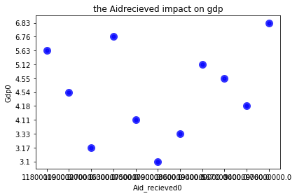

```python
Aid_recieved0= Aids
Gdp0 = gdp
plt.scatter(Aid_recieved0,Gdp0, c='blue',linewidth=5, alpha=0.8)
plt.title('the Aidrecieved impact on gdp')
plt.xlabel('Aid_recieved0')
plt.ylabel('Gdp0')
plt.tight_layout()
plt.show()
```

#### Acording to the data shape in visualization , the aid recieved doesn't has impact for gdp

### Research Question 2 (The highest growth contries in 2010!)

```python
#sort data for top 10 gdp in 2010
def top_gdp():
    top_gdp=GDP2.sort_values('2010', ascending=False).head(10)
    return top_gdp
```

```python
top_gdp()
```

|  | country | 1801 | 1802 | 1803 | 1804 | 1805 | 1806 | 1807 | 1808 | 1809 | ... | 2004 | 2005 | 2006 | 2007 | 2008 | 2009 | 2010 | 2011 | 2012 | 2013 |
| --- | --- | --- | --- | --- | --- | --- | --- | --- | --- | --- | --- | --- | --- | --- | --- | --- | --- | --- | --- | --- | --- |
| 129 | Oman | 0.0236 | 0.0236 | 0.0236 | 0.0236 | 0.0236 | 0.0236 | 0.0236 | 0.0236 | 0.0236 | ... | 3.76 | 4.53 | 6.07 | 7.49 | 14.000 | 2.620 | 24.00 | -10.10 | 3.83 | 3.69 |
| 140 | Qatar | 0.0236 | 0.0236 | 0.0236 | 0.0236 | 0.0236 | 0.0236 | 0.0236 | 0.0236 | 0.0236 | ... | 25.80 | 16.90 | 28.20 | 20.70 | 18.000 | 13.300 | 23.90 | 15.50 | 2.42 | -1.62 |
| 76 | India | 0.1710 | 0.1710 | 0.1710 | 0.1710 | 0.1710 | 0.1710 | 0.1710 | 0.1710 | 0.1710 | ... | 8.39 | 7.97 | 9.62 | 9.22 | 7.130 | 5.070 | 11.20 | 7.75 | 4.76 | 4.37 |
| 178 | Turkey | 0.3290 | 0.3290 | 0.3290 | 0.3290 | 0.3290 | 0.3290 | 0.3290 | 0.3290 | 0.3290 | ... | 8.76 | 7.26 | 7.04 | 4.84 | 0.735 | -4.870 | 9.09 | 8.42 | 2.09 | 3.27 |
| 193 | Zimbabwe | 0.1060 | 0.1060 | 0.1060 | 0.1060 | 0.1060 | 0.1060 | 0.1060 | 0.1060 | 0.1060 | ... | -6.07 | -6.04 | -3.88 | -4.14 | -18.100 | 5.310 | 8.89 | 9.79 | 10.00 | 4.29 |
| 179 | Turkmenistan | 0.1040 | 0.1040 | 0.1040 | 0.1040 | 0.1040 | 0.1040 | 0.1040 | 0.1040 | 0.1040 | ... | 13.80 | 8.21 | 10.50 | 10.60 | 14.300 | 5.760 | 8.79 | 14.30 | 10.70 | 9.78 |
| 173 | Timor-Leste | 0.1830 | 0.1830 | 0.1830 | 0.1830 | 0.1830 | 0.1830 | 0.1830 | 0.1830 | 0.1830 | ... | 1.34 | 8.70 | -3.54 | 10.60 | 13.200 | 11.500 | 8.75 | 11.70 | 9.21 | 8.56 |
| 39 | Congo, Rep. | 0.2680 | 0.2680 | 0.2680 | 0.2680 | 0.2680 | 0.2680 | 0.2680 | 0.2680 | 0.2680 | ... | 3.57 | 7.65 | 6.24 | -1.59 | 5.930 | 7.500 | 8.71 | 4.46 | 3.16 | 4.47 |
| 136 | Peru | 0.0109 | 0.0108 | 0.0108 | 0.0109 | 0.0108 | 0.0108 | 0.0109 | 0.0108 | 0.0108 | ... | 2.99 | 6.17 | 7.28 | 7.81 | 9.270 | 0.377 | 8.30 | 6.45 | 5.85 | 4.61 |
| 143 | Rwanda | 0.1120 | 0.1120 | 0.1120 | 0.1120 | 0.1120 | 0.1120 | 0.1120 | 0.1120 | 0.1120 | ... | 3.25 | 5.67 | 10.10 | 6.29 | 14.400 | 7.240 | 8.20 | 9.21 | 8.93 | 5.91 |

10 rows × 214 columns

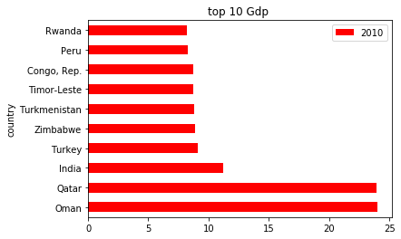

```python
top_gdp().plot.barh(x='country', y='2010',title='top 10 Gdp ', color='red')
plt.show(block=True)
```

### As the bars show the top ten contries in gdp for 2010 are :

Oman-Qatar- India- Turkey- Zembabwe-Turkmenistan-Timor-leste-Congo-Peru and Rwanda

### Research Question 3 (Copmaring number of malaria death and murder death in Nigeria in 2005!)

```python
#query for malari death in nigeria
malaria_death4[malaria_death4.country=="Nigeria"].head()
```

|  | country | 1990 | 1991 | 1992 | 1993 | 1994 | 1995 | 1996 | 1997 | 1998 | 1999 | 2000 | 2001 | 2002 | 2003 | 2004 | 2005 | 2006 |
| --- | --- | --- | --- | --- | --- | --- | --- | --- | --- | --- | --- | --- | --- | --- | --- | --- | --- | --- |
| 64 | Nigeria | 2280.0 | 1950.0 | 1070.0 | 710.0 | 1690.0 | 3270.0 | 4770.0 | 4600.0 | 6200.0 | 4120.0 | 5670.0 | 4320.0 | 4090.0 | 5340.0 | 6030.0 | 6490.0 | 6590.0 |

```python
malaria_death5=malaria_death4[malaria_death4.country=="Nigeria"]
```

```python
malaria_death5[['2005']]
```

|  | 2005 |
| --- | --- |
| 64 | 6490.0 |

```python
malaria_deaths=malaria_death5[['2005']]
```

```python
Murder_deaths[Murder_deaths.country=="Nigeria"].head()
```

|  | country | 1990 | 1991 | 1992 | 1993 | 1994 | 1995 | 1996 | 1997 | 1998 | ... | 2007 | 2008 | 2009 | 2010 | 2011 | 2012 | 2013 | 2014 | 2015 | 2016 |
| --- | --- | --- | --- | --- | --- | --- | --- | --- | --- | --- | --- | --- | --- | --- | --- | --- | --- | --- | --- | --- | --- |
| 122 | Nigeria | 804.0 | 830.0 | 858.0 | 877.0 | 870.0 | 867.0 | 879.0 | 890.0 | 902.0 | ... | 1060.0 | 1050.0 | 1100.0 | 1130.0 | 1150.0 | 1180.0 | 1210.0 | 1240.0 | 1260.0 | 1270.0 |

1 rows × 28 columns

```python
murder_death=Murder_deaths[Murder_deaths.country=="Nigeria"]
```

```python
murder_death[['2005']]
```

|  | 2005 |
| --- | --- |
| 122 | 1010.0 |

```python
murder_death0=murder_death[['2005']]
```

[figure not shown]

```python
#compare number of death becaue of malaria and because of murder
plt.bar(x= ['murder','malaria'], height= [1010.0,6490.0])
plt.title('murder vs malaria');
```

## Limitations

We get important information above but it's an old data, so it didn't match the current economic situation for any country in addition to alot of missing values.

```python
from subprocess import call
call(['python', '-m', 'nbconvert', 'Investigate_a_Dataset.ipynb'])
```

```
0
```